# STAT418 Assignment 4

Rui Qiao

6/4/2017

## SUSY Data Set

Detailed description: https://archive.ics.uci.edu/ml/datasets/SUSY

“This is a classification problem to distinguish between a signal process which produces supersymmetric particles and a background process which does not.”

“The first column is the class label (1 for signal, 0 for background), followed by the 18 features (8 low-level features then 10 high-level features). The first 8 features are kinematic properties measured by the particle detectors in the accelerator. The last ten features are functions of the first 8 features; these are high-level features derived by physicists to help discriminate between the two classes.”

The original data file (“SUSY.csv”) contains 5,000,000 observations and has file size of 2.39 GB. Uploading that file to the H2O cluster will generate an error (java.lang.OutOfMemoryError: Java heap space). H2O recommends that the memory should be four times the size of the data. Since the memory of my computer is 8GB, I decided to use a much smaller dataset.

I want to reduce the observations to 250,000. Besides deleting observations, I chose to delete all the low-level features in the dataset, leaving only high-level features as the predictor variables and the class label as the response. (An alternative way here to reduce file size can be spliting the file with 80% of observations.)

This gives me a file named as “SUSY_high_aa” with 250,000 rows and 11 columns.

## Data Loading and Preparation

```r
# h2o.shutdown()
library(h2o)
h2o.init(nthreads = -1)
```

```
##
## H2O is not running yet, starting it now...
##
## Note:  In case of errors look at the following log files:
##     /var/folders/59/8nfp64tj00b2847bjhwdp87h0000gn/T//RtmpStWfns/h2o_rachel_started_from_r.out
##     /var/folders/59/8nfp64tj00b2847bjhwdp87h0000gn/T//RtmpStWfns/h2o_rachel_started_from_r.err
##
##
## Starting H2O JVM and connecting: ....... Connection successful!
##
## R is connected to the H2O cluster:
##     H2O cluster uptime:         11 seconds 368 milliseconds
##     H2O cluster version:        3.10.4.6
##     H2O cluster version age:    1 month and 11 days
##     H2O cluster name:           H2O_started_from_R_rachel_bcx628
##     H2O cluster total nodes:    1
##     H2O cluster total memory:   1.78 GB
##     H2O cluster total cores:    0
##     H2O cluster allowed cores:  0
##     H2O cluster healthy:        TRUE
##     H2O Connection ip:          localhost
##     H2O Connection port:        54321
##     H2O Connection proxy:       NA
##     H2O Internal Security:      FALSE
##     R Version:                  R version 3.3.2 (2016-10-31)
```

```r
col_names <- c("class", "MET_rel", "axial MET", "M_R", "M_TR_2", "R",
               "MT2", "S_R", "M_Delta_R", "dPhi_r_b", "cos(theta_r1)")

SUSY <- h2o.importFile("/Users/Rachel/Desktop/STAT418/SUSY/SUSY_high_aa",
                       destination_frame = "SUSY", col.names = col_names)
y <- "class"
x <- setdiff(names(SUSY),y)

# For binary classification, response should be a factor
SUSY[y] <- as.factor(SUSY[y])
summary(SUSY[y])
```

```
##  class
##  0:135621
##  1:114379
```

```r
# 1 for signal, 0 for background

# Split Data: train-valid-test
# Do not use cross-validation, dataset is large enough
parts <- h2o.splitFrame(SUSY, c(0.8,0.1), seed = 123)
SUSY_train <- parts[[1]]
SUSY_valid <- parts[[2]]
SUSY_test <- parts[[3]]
rm(parts)
```

## Neutral Networks

Try various architectures, tricks (initialization, regularization, momentum, adaptive learning rate etc.).Use early stopping. To reduce the Knit time of Rmarkdown file, the models are not shown in this filw but in a seperate file, NN_models.rmd (/NN_models.html).

By comparing AUC of 21 different Neutral Networks, the best model is found. The model uses almost all default settings. It uses Rectifier activation function ( outputs the sum of its weighted inputs, but clips all negative values to zero). No lasso or ridge regularization (l1, l2 = 0). Learning rate is default 0.005, momentum_stable = 0. It uses early stopping: If AUC does not improve in the last 2 scoring rounds, the process stops.

```r
system.time({
  model_NN <- h2o.deeplearning(x = x, y = y, training_frame = SUSY_train, validation_frame = SUSY_valid,
            activation = "Rectifier", hidden = c(200,200),
            adaptive_rate = FALSE, ## default: rate = 0.005, rate_decay = 1, momentum_stable = 0,
            epochs = 100, stopping_rounds = 2, stopping_metric = "AUC", stopping_tolerance = 0)
})
```

```
##    user  system elapsed
##   0.850   0.047  77.362
```

```r
h2o.performance(model_NN, SUSY_test)@metrics$AUC
```

```
## [1] 0.8625759
```

## Hyperparameter optimization for GBMs with random search

```r
hyper_params <- list(ntrees = 10000,  ## early stopping
                     max_depth = 5:15,
                     min_rows = c(1,3,10,30,100),
                     learn_rate = c(0.01,0.03,0.1),
                     learn_rate_annealing = c(0.99,0.995,1,1),
                     sample_rate = c(0.4,0.7,1,1),
                     col_sample_rate = c(0.7,1,1),
                     nbins = c(30,100,300),
                     nbins_cats = c(64,256,1024)
)

search_criteria <- list( strategy = "RandomDiscrete",
                        max_runtime_secs = 10*3600,
                        max_models = 100
)

system.time({
  GBM_grid <- h2o.grid(algorithm = "gbm", grid_id = "SUSY_GBM_grid",
                  x = x, y = y, training_frame = SUSY_train,
                  validation_frame = SUSY_valid,
                  hyper_params = hyper_params,
                  search_criteria = search_criteria,
                  stopping_metric = "AUC", stopping_tolerance = 0.02, stopping_rounds = 2,
                  seed = 123)
})
```

```
##    user  system elapsed
##   8.166   0.524 591.123
```

```r
GBM_auc <- h2o.getGrid(grid_id = "SUSY_GBM_grid", sort_by = "auc", decreasing = TRUE)
GBM_auc
```

```
## H2O Grid Details
## ================
##
## Grid ID: SUSY_GBM_grid
## Used hyper parameters:
##   -  col_sample_rate
##   -  learn_rate
##   -  learn_rate_annealing
##   -  max_depth
##   -  min_rows
##   -  nbins
##   -  nbins_cats
##   -  ntrees
##   -  sample_rate
## Number of models: 100
## Number of failed models: 0
##
## Hyper-Parameter Search Summary: ordered by decreasing auc
##   col_sample_rate learn_rate learn_rate_annealing max_depth min_rows nbins
## 1             0.7       0.01                  1.0        15      3.0   300
## 2             1.0       0.03                 0.99        15      1.0    30
## 3             0.7       0.01                 0.99        15      3.0    30
## 4             1.0       0.03                  1.0        15      1.0   300
## 5             1.0       0.01                 0.99        15      1.0    30
##   nbins_cats ntrees sample_rate              model_ids                auc
## 1         64  10000         0.4 SUSY_GBM_grid_model_78 0.8641898799718385
## 2        256  10000         0.4  SUSY_GBM_grid_model_2 0.8636278946500344
## 3       1024  10000         1.0  SUSY_GBM_grid_model_8 0.8612298713976013
## 4        256  10000         0.4 SUSY_GBM_grid_model_99 0.8608254370258581
## 5       1024  10000         0.4 SUSY_GBM_grid_model_90 0.8607967424724873
##
## ---
##     col_sample_rate learn_rate learn_rate_annealing max_depth min_rows
## 95              1.0       0.01                  1.0         6     30.0
## 96              0.7       0.03                 0.99         5     10.0
## 97              1.0       0.01                 0.99         5    100.0
## 98              1.0       0.01                  1.0         5    100.0
## 99              1.0       0.01                  1.0        14      1.0
## 100             1.0       0.01                  1.0        14      1.0
##     nbins nbins_cats ntrees sample_rate              model_ids
## 95     30        256  10000         1.0 SUSY_GBM_grid_model_72
## 96    300       1024  10000         0.7 SUSY_GBM_grid_model_14
## 97    100        256  10000         1.0 SUSY_GBM_grid_model_37
## 98    100       1024  10000         1.0 SUSY_GBM_grid_model_40
## 99    100       1024  10000         1.0 SUSY_GBM_grid_model_95
## 100   100         64  10000         1.0 SUSY_GBM_grid_model_11
##                    auc
## 95  0.8352677621221525
## 96  0.8340762949582186
## 97  0.8262424521740488
## 98  0.8262424521740488
## 99  0.8255557321800555
## 100 0.8255557321800555
```

```r
model_GBM <- h2o.getModel(GBM_grid@model_ids[[1]])
summary(model_GBM)
```

```
## Model Details:
## ==============
##
## H2OBinomialModel: gbm
## Model Key:  SUSY_GBM_grid_model_2
## Model Summary:
##   number_of_trees number_of_internal_trees model_size_in_bytes min_depth
## 1             279                      279            27401441        15
##   max_depth mean_depth min_leaves max_leaves mean_leaves
## 1        15   15.00000       3989       9307  7825.88200
##
## H2OBinomialMetrics: gbm
## ** Reported on training data. **
##
## MSE:  0.08999897
## RMSE:  0.2999983
## LogLoss:  0.3129667
## Mean Per-Class Error:  0.1121244
## AUC:  0.9541188
## Gini:  0.9082376
##
## Confusion Matrix (vertical: actual; across: predicted) for F1-optimal threshold:
##             0     1    Error           Rate
## 0      100580  7985 0.073550   =7985/108565
## 1       13799 77768 0.150698   =13799/91567
## Totals 114379 85753 0.108848  =21784/200132
##
## Maximum Metrics: Maximum metrics at their respective thresholds
##                         metric threshold    value idx
## 1                       max f1  0.422901 0.877149 215
## 2                       max f2  0.253749 0.892579 288
## 3                 max f0point5  0.575149 0.922130 162
## 4                 max accuracy  0.455361 0.892541 203
## 5                max precision  0.968339 1.000000   0
## 6                   max recall  0.095889 1.000000 387
## 7              max specificity  0.968339 1.000000   0
## 8             max absolute_mcc  0.484659 0.785755 193
## 9   max min_per_class_accuracy  0.364989 0.881180 237
## 10 max mean_per_class_accuracy  0.443119 0.888196 207
##
```

[output cut: 71 more lines]

```
## Variable Importances: (Extract with `h2o.varimp`)
## =================================================
##
## Variable Importances:
##         variable relative_importance scaled_importance percentage
## 1         M_TR_2       257887.343750          1.000000   0.326559
## 2      axial MET       110482.539062          0.428414   0.139903
## 3        MET_rel        75731.195312          0.293660   0.095897
## 4  cos(theta_r1)        61261.050781          0.237550   0.077574
## 5       dPhi_r_b        61156.390625          0.237144   0.077442
## 6      M_Delta_R        52221.953125          0.202499   0.066128
## 7            M_R        48896.429688          0.189604   0.061917
## 8            MT2        43102.101562          0.167135   0.054580
## 9              R        42839.632812          0.166118   0.054247
## 10           S_R        36131.492188          0.140106   0.045753
```

```r
h2o.auc(h2o.performance(model_GBM, SUSY_test))
```

```
## [1] 0.8603226
```

## Ensembles

I want to find an ensemble of the best models with highest auc in each category (Logistic Regression, Random Forest, Neutral Networks, GBM).

```r
nfolds = 5

system.time({
  m1 <- h2o.glm(x, y, training_frame = SUSY_train,
                      validation_frame = SUSY_valid,
                      family = "binomial",alpha = 1.0,
                      lambda = 0,
                      seed = 123,
                      nfolds = nfolds,
                      fold_assignment = "Modulo",
                      keep_cross_validation_predictions = TRUE)
})
```

```
##    user  system elapsed
##   0.237   0.008   6.443
```

```r
system.time({
  m2 <- h2o.randomForest(x = x, y = y, training_frame = SUSY_train,
                 validation_frame = SUSY_valid,
                 max_depth = 20, mtries = 3, ntrees =50,
                 seed = 123,
                 nfolds = nfolds,
                 fold_assignment = "Modulo",
                 keep_cross_validation_predictions = TRUE)
})
```

```
##    user  system elapsed
##   1.354   0.089 165.997
```

```r
system.time({
  m3 <- h2o.deeplearning(x = x, y = y, training_frame = SUSY_train, validation_frame = SUSY_valid,
            epochs = 5,
            seed = 123,
            nfolds = nfolds,
            fold_assignment = "Modulo",
            keep_cross_validation_predictions = TRUE)
})
```

```
##    user  system elapsed
##   2.052   0.125 266.505
```

```r
system.time({
  m4 <- h2o.gbm(x, y, training_frame = SUSY_train,
                validation_frame = SUSY_valid,
                ntrees = 200,
                max_depth = 10,
                learn_rate = 0.1,
                nbins = 100,
                seed = 123,
                nfolds = nfolds,
                fold_assignment = "Modulo",
                keep_cross_validation_predictions = TRUE)
})
```

```
##    user  system elapsed
##   1.389   0.090 168.915
```

```r
model_ENS <- h2o.stackedEnsemble(x = x, y = y, training_frame = SUSY_train,
                              base_models = list(m1@model_id, m2@model_id,
                                       m3@model_id, m4@model_id))
```

## Summary Evaluation

### AUC table

```r
s1 <- h2o.auc(h2o.performance(m1, SUSY_test))
s2 <- h2o.auc(h2o.performance(m2, SUSY_test))
s3 <- h2o.auc(h2o.performance(model_NN, SUSY_test))
s4 <- h2o.auc(h2o.performance(model_GBM, SUSY_test))
s5 <- h2o.auc(h2o.performance(model_ENS, SUSY_test))

a <-as.data.frame(cbind(c("LR", "RF", "NN","GBM","Ensembles"), c(s1,s2,s3,s4,s5)))
names(a) <- c("Model", "AUC")
a
```

```
##       Model               AUC
## 1        LR 0.832734961041142
## 2        RF 0.857638065518827
## 3        NN 0.862575933787254
## 4       GBM 0.860322591670169
## 5 Ensembles 0.863019617579101
```

### ROC plots

ROC plot is the plot of the true positive rate against the false positive rate for the different possible cutpoints of a diagnostic test. It shows the tradeoff between sensitivity and specificity (any increase in sensitivity will be accompanied by a decrease in specificity). The closer the curve follows the left-hand border and then the top border of the ROC space, the more accurate the test. The closer the curve comes to the 45-degree diagonal of the ROC space, the less accurate the test.

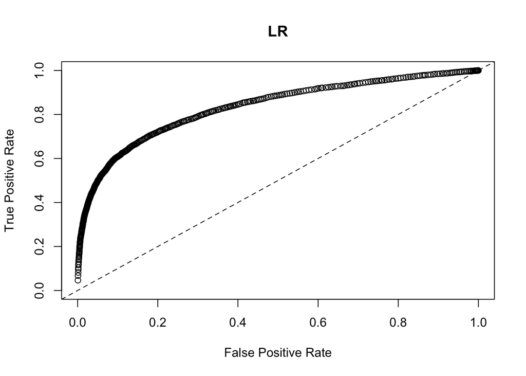

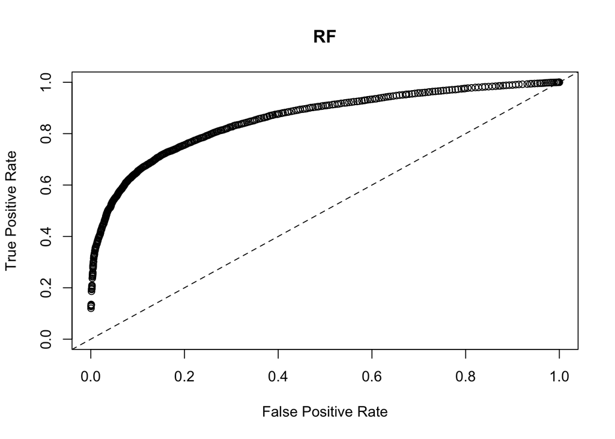

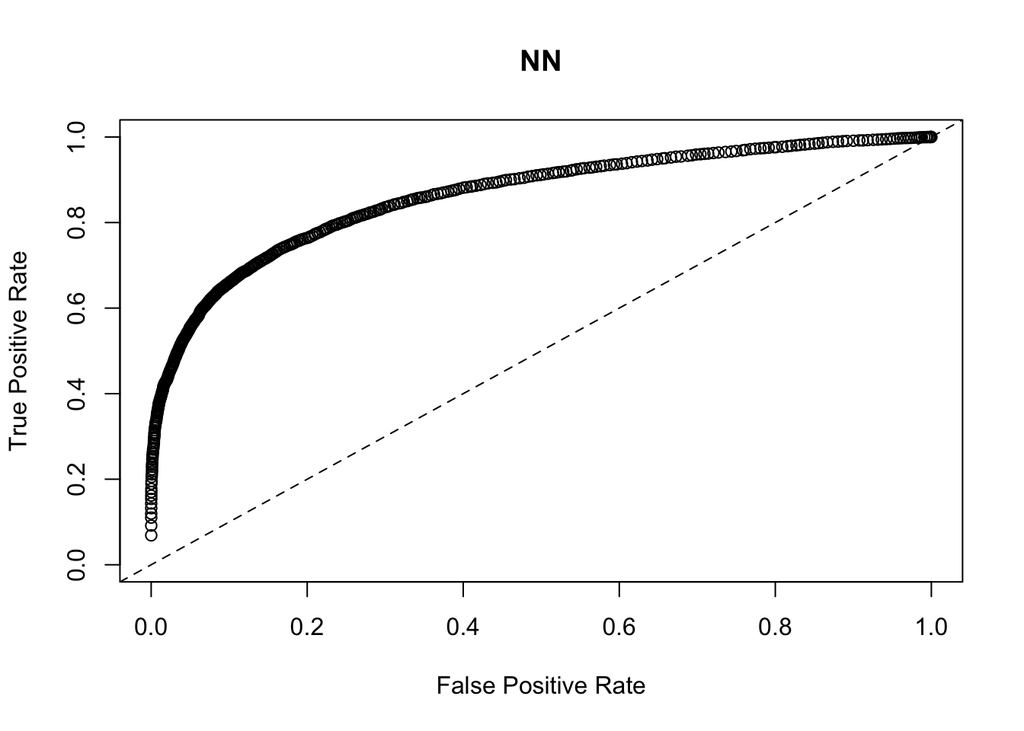

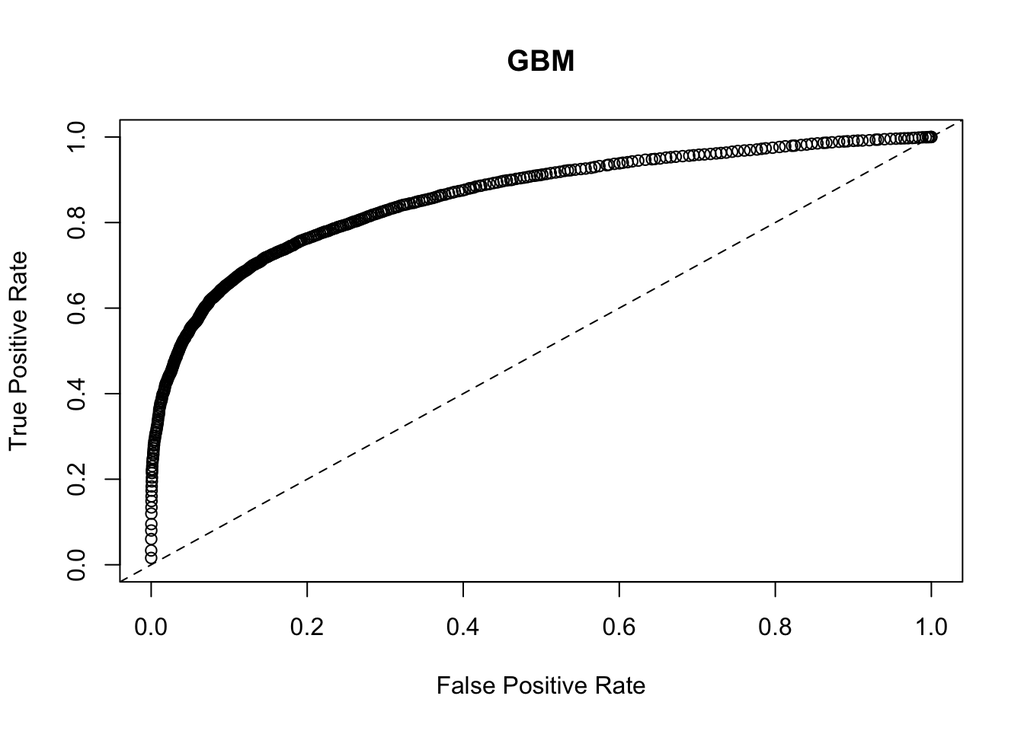

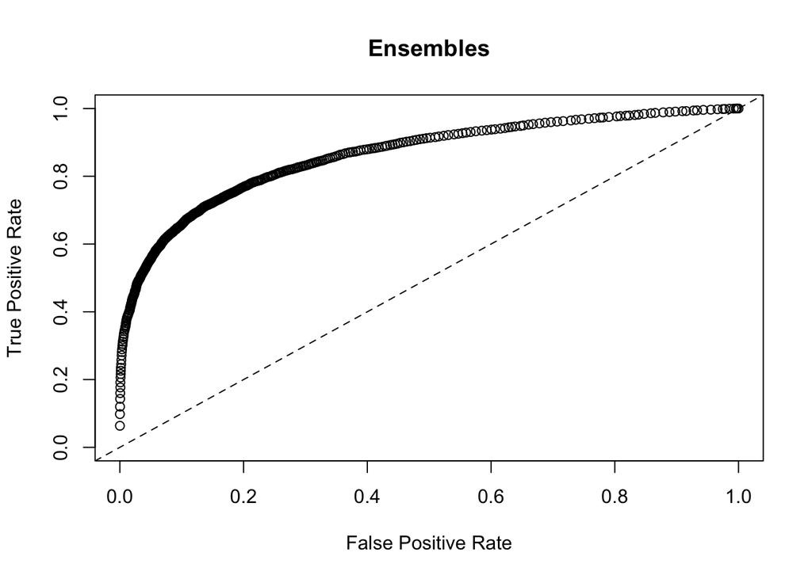

## Model Performance (Selected models)

### Logistic Regression

```r
h2o.performance(m1, SUSY_test)
```

```
## H2OBinomialMetrics: glm
##
## MSE:  0.1616076
## RMSE:  0.4020045
## LogLoss:  0.4950213
## Mean Per-Class Error:  0.2471767
## AUC:  0.832735
## Gini:  0.6654699
## R^2:  0.349345
## Null Deviance:  34607.1
## Residual Deviance:  24831.26
## AIC:  24853.26
##
## Confusion Matrix (vertical: actual; across: predicted) for F1-optimal threshold:
##            0     1    Error         Rate
## 0      10010  3541 0.261309  =3541/13551
## 1       2687  8843 0.233044  =2687/11530
## Totals 12697 12384 0.248315  =6228/25081
##
## Maximum Metrics: Maximum metrics at their respective thresholds
##                         metric threshold    value idx
## 1                       max f1  0.375651 0.739567 236
## 2                       max f2  0.175423 0.817016 338
## 3                 max f0point5  0.572782 0.782135 154
## 4                 max accuracy  0.494085 0.768988 186
## 5                max precision  0.998962 0.984752   1
## 6                   max recall  0.006842 1.000000 399
## 7              max specificity  0.999856 0.999336   0
## 8             max absolute_mcc  0.560511 0.538825 159
## 9   max min_per_class_accuracy  0.388360 0.753599 230
## 10 max mean_per_class_accuracy  0.444020 0.762249 206
##
## Gains/Lift Table: Extract with `h2o.gainsLift(<model>, <data>)` or `h2o.gainsLift(<model>, valid=<T/F>, xval=<T/F>)`
```

### Random Forest

```r
h2o.performance(m2, SUSY_test)
```

```
## H2OBinomialMetrics: drf
##
## MSE:  0.148682
## RMSE:  0.385593
## LogLoss:  0.4633558
## Mean Per-Class Error:  0.2295084
## AUC:  0.8576381
## Gini:  0.7152761
##
## Confusion Matrix (vertical: actual; across: predicted) for F1-optimal threshold:
##            0     1    Error         Rate
## 0       9987  3564 0.263006  =3564/13551
## 1       2260  9270 0.196010  =2260/11530
## Totals 12247 12834 0.232208  =5824/25081
##
## Maximum Metrics: Maximum metrics at their respective thresholds
##                         metric threshold    value idx
## 1                       max f1  0.349414 0.760959 236
## 2                       max f2  0.152601 0.829697 334
## 3                 max f0point5  0.629842 0.804254 132
## 4                 max accuracy  0.493769 0.788485 181
## 5                max precision  0.999994 0.995693   0
## 6                   max recall  0.036231 1.000000 396
## 7              max specificity  0.999994 0.999557   0
## 8             max absolute_mcc  0.566136 0.577173 156
## 9   max min_per_class_accuracy  0.386749 0.774998 221
## 10 max mean_per_class_accuracy  0.480707 0.782746 185
##
## Gains/Lift Table: Extract with `h2o.gainsLift(<model>, <data>)` or `h2o.gainsLift(<model>, valid=<T/F>, xval=<T/F>)`
```

### Neutrual Network

```r
h2o.performance(model_NN, SUSY_test)
```

```
## H2OBinomialMetrics: deeplearning
##
## MSE:  0.1462042
## RMSE:  0.3823666
## LogLoss:  0.4487284
## Mean Per-Class Error:  0.2201525
## AUC:  0.8625759
## Gini:  0.7251519
##
## Confusion Matrix (vertical: actual; across: predicted) for F1-optimal threshold:
##            0     1    Error         Rate
## 0      10391  3160 0.233193  =3160/13551
## 1       2388  9142 0.207112  =2388/11530
## Totals 12779 12302 0.221203  =5548/25081
##
## Maximum Metrics: Maximum metrics at their respective thresholds
##                         metric threshold    value idx
## 1                       max f1  0.376157 0.767204 231
## 2                       max f2  0.210642 0.830846 314
## 3                 max f0point5  0.635132 0.808406 134
## 4                 max accuracy  0.515313 0.791197 175
## 5                max precision  0.993254 0.999395   5
## 6                   max recall  0.042869 1.000000 398
## 7              max specificity  0.999797 0.999926   0
## 8             max absolute_mcc  0.568628 0.582690 157
## 9   max min_per_class_accuracy  0.389710 0.780238 225
## 10 max mean_per_class_accuracy  0.448551 0.786384 202
##
## Gains/Lift Table: Extract with `h2o.gainsLift(<model>, <data>)` or `h2o.gainsLift(<model>, valid=<T/F>, xval=<T/F>)`
```

### GBM

```r
h2o.performance(model_GBM, SUSY_test)
```

```
## H2OBinomialMetrics: gbm
##
## MSE:  0.1472797
## RMSE:  0.3837704
## LogLoss:  0.4540343
## Mean Per-Class Error:  0.2170805
## AUC:  0.8603226
## Gini:  0.7206452
##
## Confusion Matrix (vertical: actual; across: predicted) for F1-optimal threshold:
##            0     1    Error         Rate
## 0      10962  2589 0.191056  =2589/13551
## 1       2803  8727 0.243105  =2803/11530
## Totals 13765 11316 0.214983  =5392/25081
##
## Maximum Metrics: Maximum metrics at their respective thresholds
##                         metric threshold    value idx
## 1                       max f1  0.412239 0.763985 219
## 2                       max f2  0.169673 0.831870 339
## 3                 max f0point5  0.640818 0.807720 136
## 4                 max accuracy  0.507304 0.791715 183
## 5                max precision  0.968307 1.000000   0
## 6                   max recall  0.073865 1.000000 398
## 7              max specificity  0.968307 1.000000   0
## 8             max absolute_mcc  0.538535 0.582365 172
## 9   max min_per_class_accuracy  0.377507 0.777360 232
## 10 max mean_per_class_accuracy  0.477207 0.785932 194
##
## Gains/Lift Table: Extract with `h2o.gainsLift(<model>, <data>)` or `h2o.gainsLift(<model>, valid=<T/F>, xval=<T/F>)`
```

### Ensembles

```r
h2o.performance(model_ENS, SUSY_test)
```

```
## H2OBinomialMetrics: stackedensemble
##
## MSE:  0.1472736
## RMSE:  0.3837624
## LogLoss:  0.4553012
## Mean Per-Class Error:  0.2162438
## AUC:  0.8630196
## Gini:  0.7260392
##
## Confusion Matrix (vertical: actual; across: predicted) for F1-optimal threshold:
##            0     1    Error         Rate
## 0      10665  2886 0.212973  =2886/13551
## 1       2531  8999 0.219514  =2531/11530
## Totals 13196 11885 0.215980  =5417/25081
##
## Maximum Metrics: Maximum metrics at their respective thresholds
##                         metric threshold    value idx
## 1                       max f1  0.327873 0.768653 247
## 2                       max f2  0.141334 0.831581 347
## 3                 max f0point5  0.655998 0.808914 127
## 4                 max accuracy  0.457544 0.793230 195
## 5                max precision  0.947925 0.999116   1
## 6                   max recall  0.081732 1.000000 398
## 7              max specificity  0.948625 0.999926   0
## 8             max absolute_mcc  0.532278 0.584571 169
## 9   max min_per_class_accuracy  0.323683 0.782480 249
## 10 max mean_per_class_accuracy  0.457544 0.786957 195
##
## Gains/Lift Table: Extract with `h2o.gainsLift(<model>, <data>)` or `h2o.gainsLift(<model>, valid=<T/F>, xval=<T/F>)`
```